# Comparaison de deux moyennes

Serigne Fallou Mbacke NGOM

2023-09-16

Nous présentons ici le test classique de comparaison de deux moyennes. Pour cela nous disposons d’observations d’une variable quantitative qui sont supposées avoirété tirées aléatoirement dans deux populations (notées 1 et 2) et ce de manière indépendante. Les moyennes de la variable dans chaque population, notées µ1 et µ2, sont inconnues et nous allons tester l’égalité de ces deux moyennes au regard des données collectées.

### IMPORTER ET NETTOYAE DES DONNEES:

```r
Clinic_Data[,"SEXE" ]= factor(Clinic_Data[, "SEXE"])
levels(Clinic_Data[,'SEXE']) = c( "Femme","Homme")

data_temp_Sexe = Clinic_Data[c("TEMP","SEXE")]
summary(data_temp_Sexe)
```

```
##       TEMP          SEXE
##  Min.   :37.00   Femme:1580
##  1st Qu.:38.30   Homme:1760
##  Median :38.70
##  Mean   :38.79
##  3rd Qu.:39.20
##  Max.   :40.00
```

n1 > 30 et n2 > 30, vérifier les hypothèses de normalité n’est pas nécessaire, la loi de la statistique de test étant approchée par une loi de Student comme dans le cas gaussien.

### Comparer graphiquement les deux sous-populations:

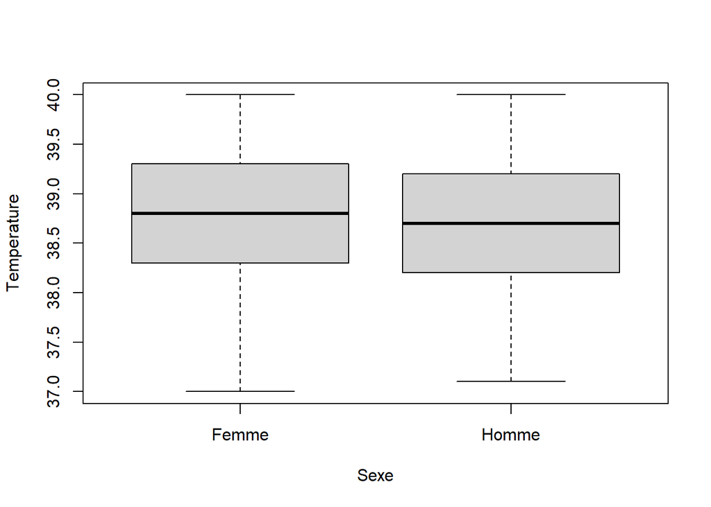

```r
boxplot(TEMP ~ SEXE, ylab="Temperature", xlab="Sexe", data=data_temp_Sexe)
```

### Estimer les statistiques de base dans chaque groupe:

```r
aggregate(data_temp_Sexe$TEMP,by=list(data_temp_Sexe$SEXE),FUN=summary)
```

```
##   Group.1   x.Min. x.1st Qu. x.Median   x.Mean x.3rd Qu.   x.Max.
## 1   Femme 37.00000  38.30000 38.80000 38.82582  39.30000 40.00000
## 2   Homme 37.10000  38.20000 38.70000 38.75773  39.20000 40.00000
```

### Tester l’égalité des variances:

La statistique de test sur laquelle s’appuie le test de comparaison de moyennes diffère selon que les variances σ2 1 et σ2 2 peuvent être considérées comme égales ou non. Le test de l’hypothèse H0 : σ2 1 = σ2 2 contre l’hypothèse alternative H1 : σ2 1 != σ2 2 s’écrit comme suit :

```r
var.test(TEMP ~ SEXE,conf.level=.95,data=data_temp_Sexe)
```

```
##
##  F test to compare two variances
##
## data:  TEMP by SEXE
## F = 1.0275, num df = 1579, denom df = 1759, p-value = 0.58
## alternative hypothesis: true ratio of variances is not equal to 1
## 95 percent confidence interval:
##  0.9334075 1.1312627
## sample estimates:
## ratio of variances
##           1.027454
```

La probabilité critique associée à ce test est 0.58 : au seuil 5 %, nous retenons H0 et considérons que les variances ne sont pas significativement différentes. Notons que le listing fournit une estimation du rapport σ2 1/σ2 2 (ratio of variances=1.027454), le numérateur correspondant par défaut à la variance empirique associée au premier niveau du facteur (ici Femme). On dispose aussi d’un intervalle de confiance pour ce rapport (95 percent confidence interval: 0.9334075 1.1312627)

### Tester l’égalité des moyennes:

```r
t.test(TEMP~SEXE, alternative="two.sided", conf.level=.95,var.equal=TRUE, data=data_temp_Sexe)
```

```
##
##  Two Sample t-test
##
## data:  TEMP by SEXE
## t = 3.2394, df = 3338, p-value = 0.001209
## alternative hypothesis: true difference in means between group Femme and group Homme is not equal to 0
## 95 percent confidence interval:
##  0.02688032 0.10931070
## sample estimates:
## mean in group Femme mean in group Homme
##            38.82582            38.75773
```

La probabilité critique associée au test (p-value = 0.001209) nous conduit à rejeter, au seuil 5 %, H0 : µ1 = µ2 au profit de H1 : µ1 != µ2. Ainsi, compte tenu des écarts-types, les moyennes observées dans l’échantillon (38.76 pour les hommes, 38.83 pour les femmes) sont suffisamment différentes pour que nous puissions considérer que les « vraies » moyennes µ1 et µ2 sont significativement différentes.

On peut aussi tester si les femmes ont des temperatures plus faibles que les hommes contre l’alternative opposée, c’est-à-dire H0 : µ1 ≤ µ2 contre H1 : µ1 > µ2.

```r
t.test(TEMP~SEXE, alternative="greater", conf.level=.95,var.equal=TRUE, data=data_temp_Sexe)
```

```
##
##  Two Sample t-test
##
## data:  TEMP by SEXE
## t = 3.2394, df = 3338, p-value = 0.0006047
## alternative hypothesis: true difference in means between group Femme and group Homme is greater than 0
## 95 percent confidence interval:
##  0.03350958        Inf
## sample estimates:
## mean in group Femme mean in group Homme
##            38.82582            38.75773
```

**Sans surprise, on accepte l’hypothèse H1 selon laquelle les femmes ont des temperatures plus elevees.**